# Eric_Hirsch_624_Homework_2

2023-02-10

Exercises 1,2,3,4,5,7,8,9

*1. Consider the GDP information in global_economy. Plot the GDP per capita for each country over time.*

There are too many time series to fit legibly on one plot. We can see, however, a general trend up.

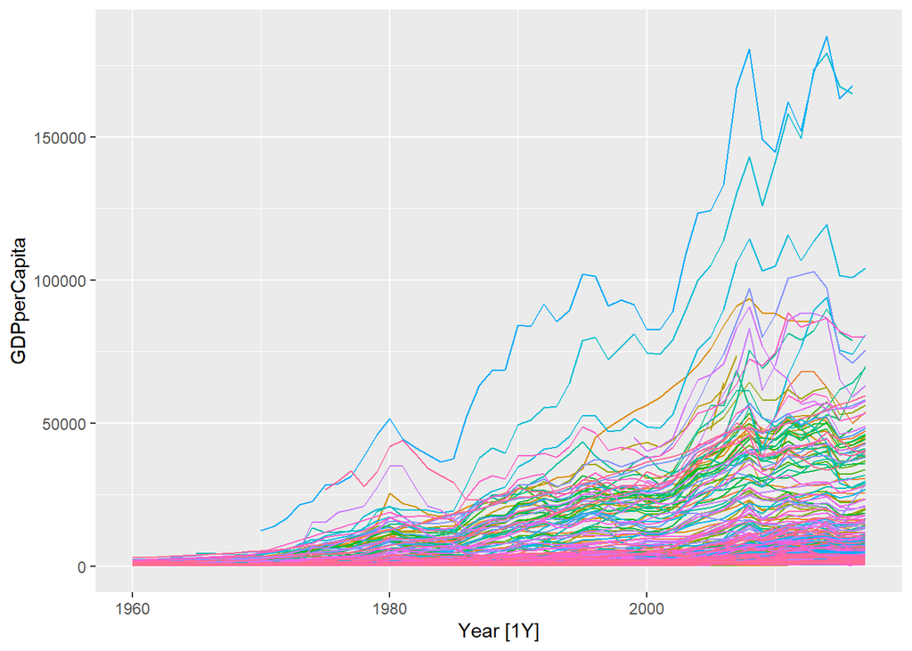

**1.b Which country has the highest GDP per capita? How has this changed over time?**

We filter GDP per capita at 80,000 and find that Monaco has the highest GDP per capita, and has since the 1990s, with some brief exceptions when Liechtenstein led GDP per capita.

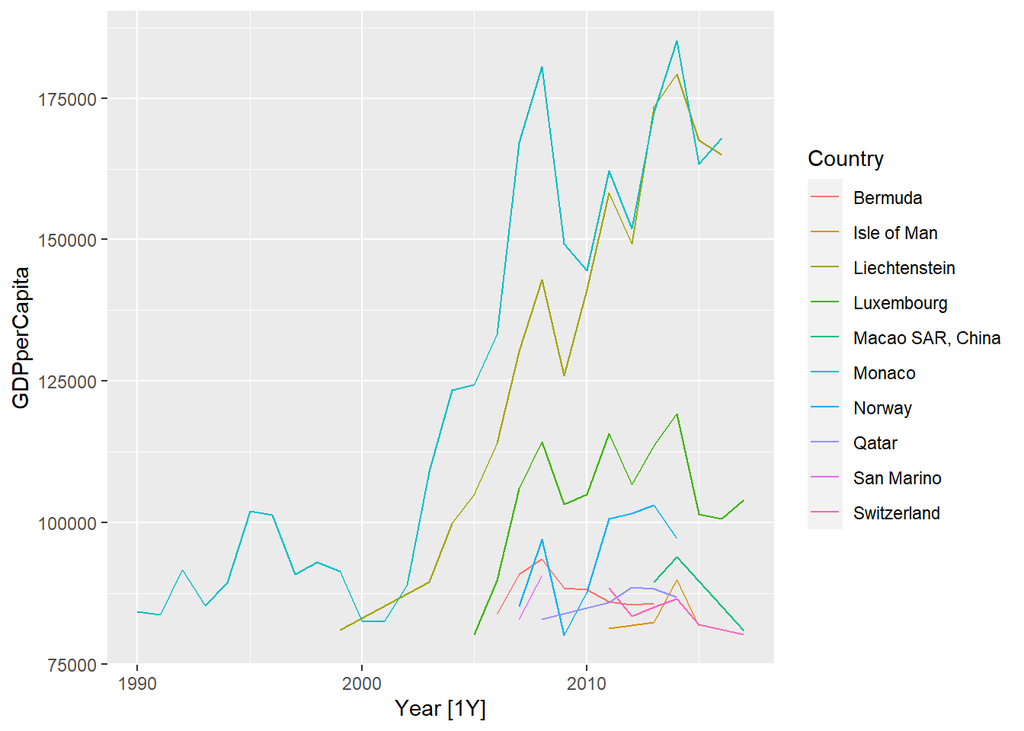

*2. For each of the following series, make a graph of the data. If transforming seems appropriate, do so and describe the effect. United States GDP from global_economy:*

The GDP per capita in the US appears to be increasing exponentially, so a log transformation seems appropriate. In fact, the log transformation is only mildly effective, though not entirely, effective.

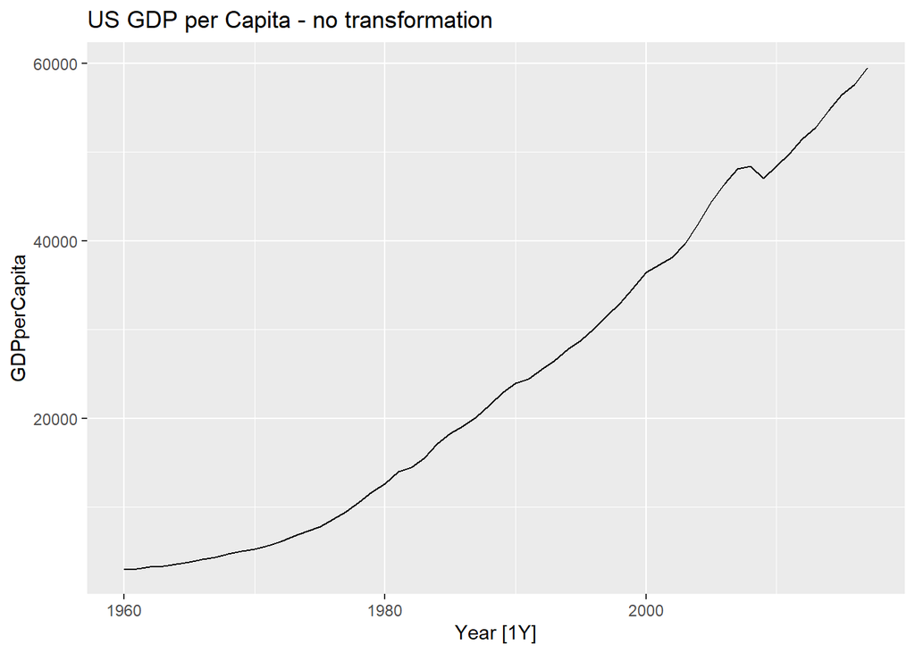

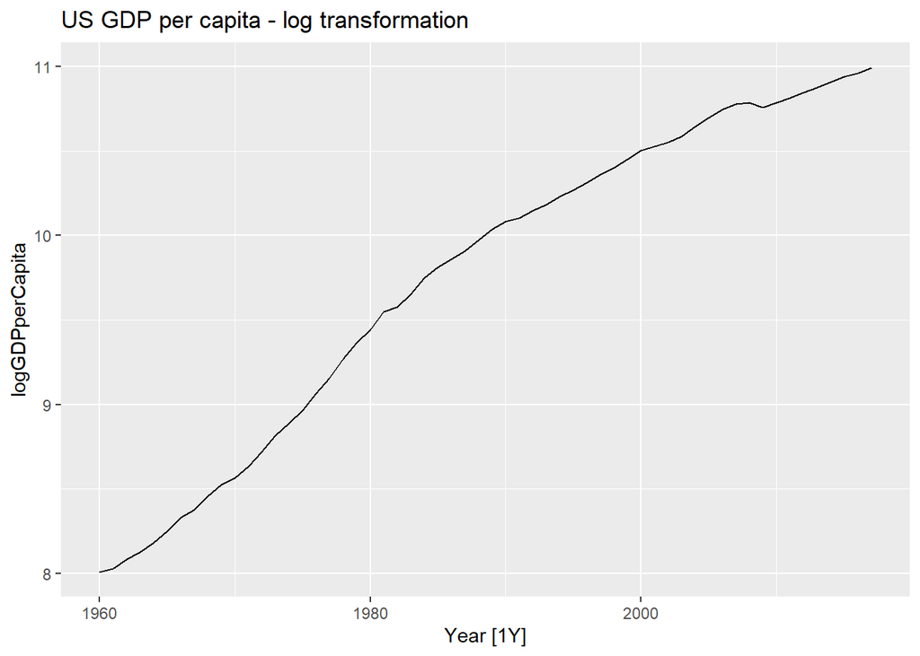

*2b. slaughter of Victorian “Bulls, bullocks and steers” in aus_livestock.*

Here we can perform a box-cox transformation to create more linearity and stabilize variation. In fact, the box cox has little effect. We can also perform a moving average (11 months works well here) to isolate the trend from the seasonality.

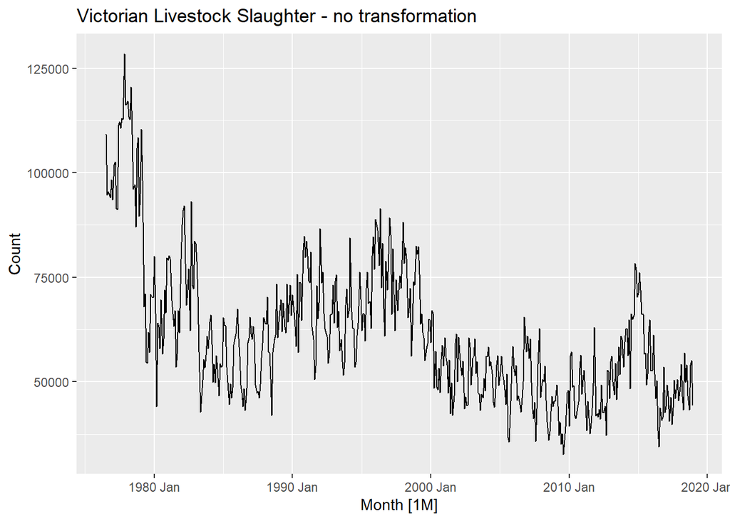

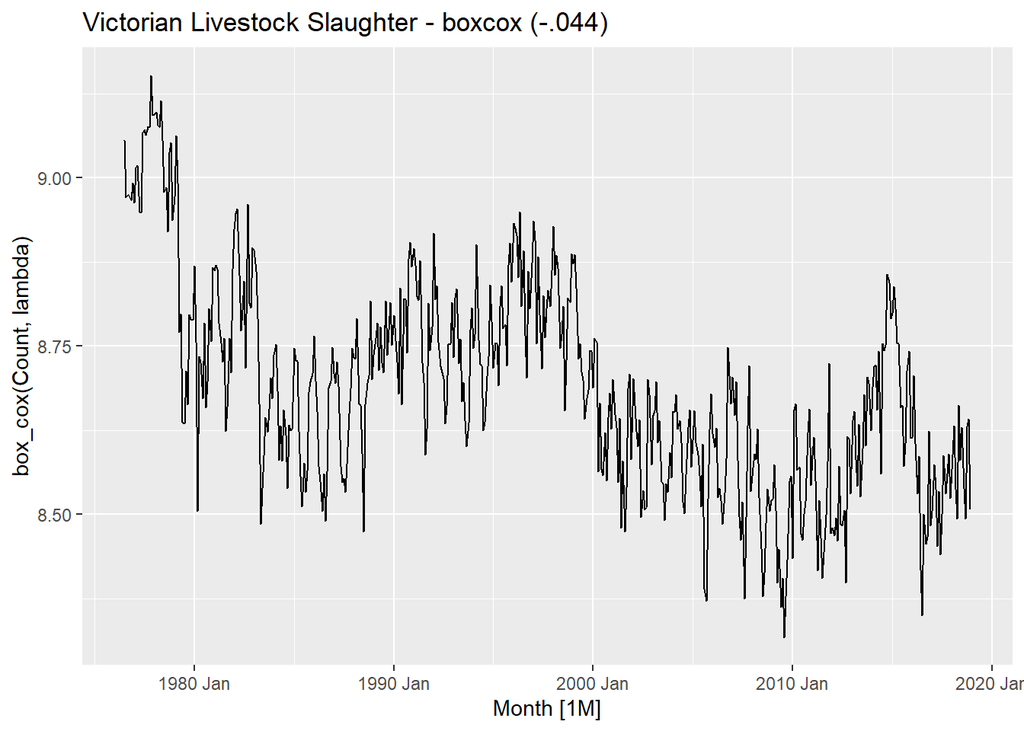

```
## [1] -0.04461887
```

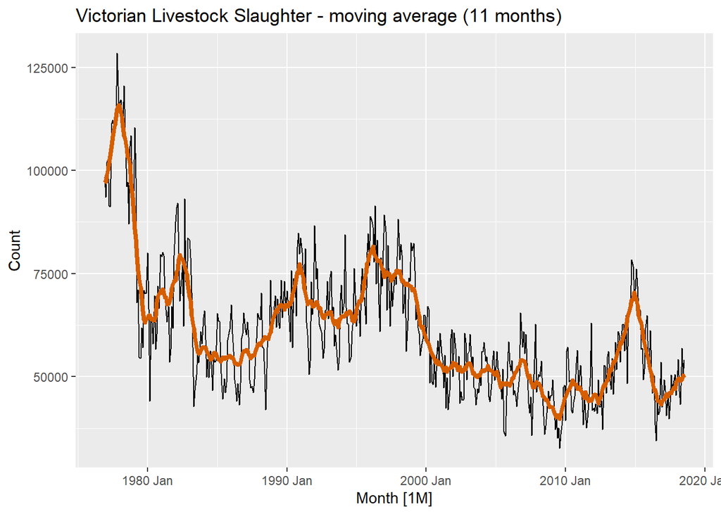

**2.c Victorian Electricity Demand from vic_elec**

For this dataset it is possible to do a moving average, but the variation renders it not very useful.

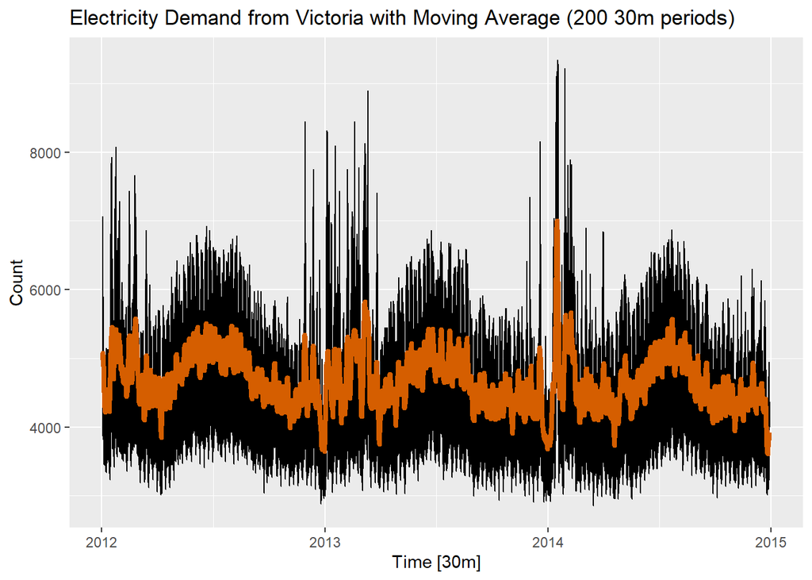

**2.d Gas production from aus_production.**

A boxcox with a .11 lambda helps make the curve more linear and significantly reduce variability.

[figure not shown]

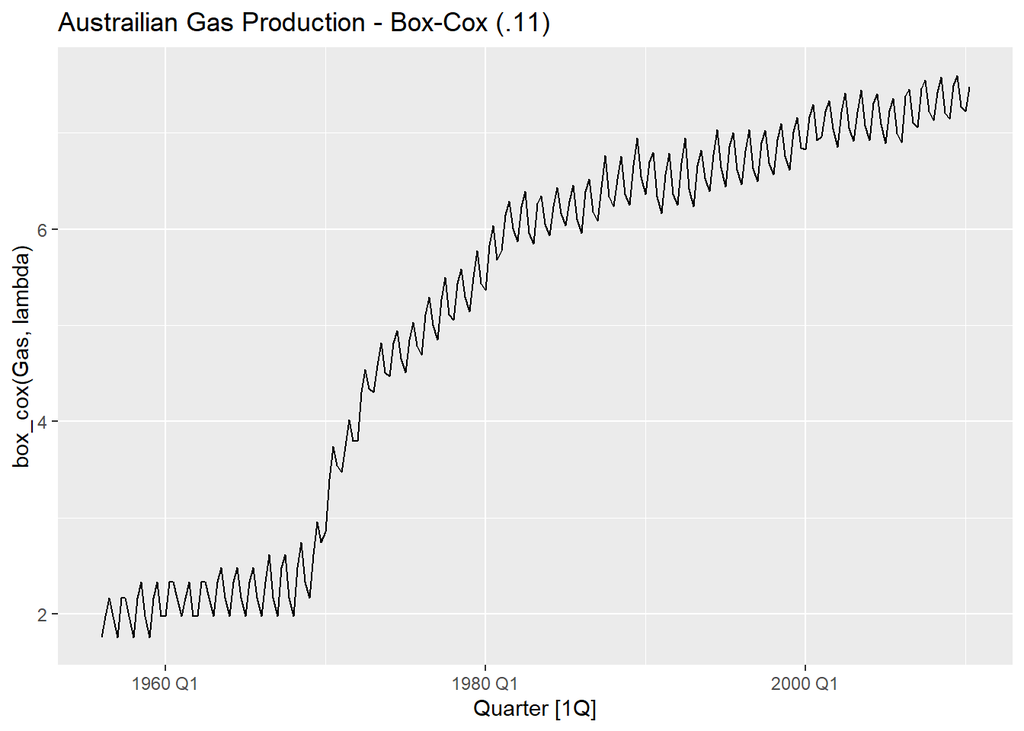

```
## [1] 0.1095171
```

*3. Why is a Box-Cox transformation unhelpful for the canadian_gas data?*

```
## # A tsibble: 6 x 2 [1M]
##      Month Volume
##      <mth>  <dbl>
## 1 1960 Jan   1.43
## 2 1960 Feb   1.31
## 3 1960 Mar   1.40
## 4 1960 Apr   1.17
## 5 1960 May   1.12
## 6 1960 Jun   1.01
```

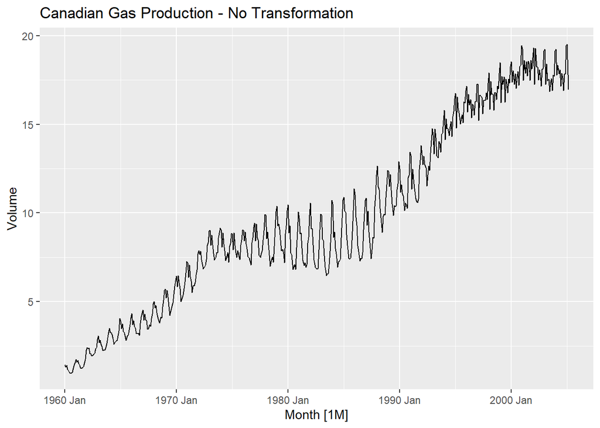

[figure not shown]

```
## [1] 0.5767648
```

*4. What Box-Cox transformation would you select for your retail data (from Exercise 8 in Section 2.10)?*

Using guerrerro, the best lambda is .22. The difference is moderate, maving the effect of smoothing out the large jump toward the end of the year.

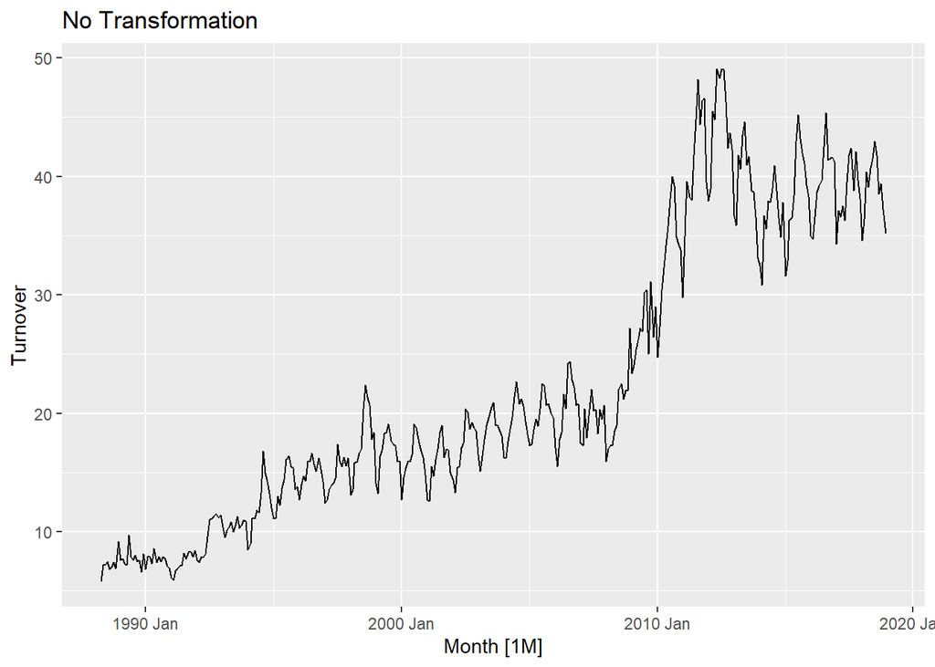

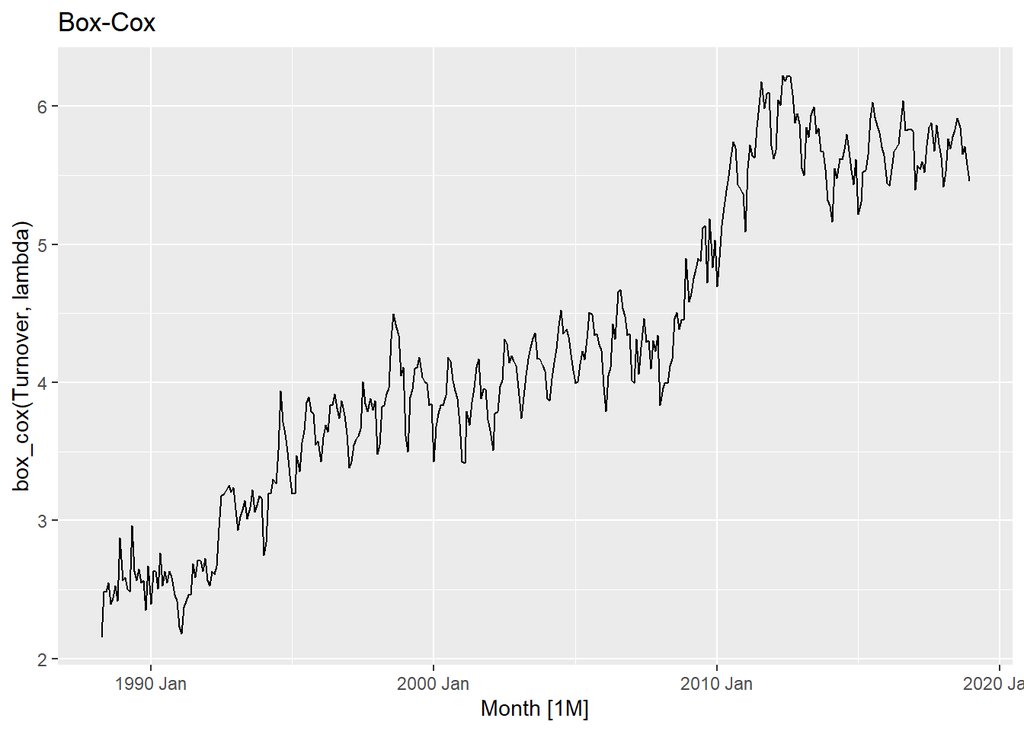

```
## [1] 0.2247137
```

**5. For the following series, find an appropriate Box-Cox transformation in order to stabilise the variance. Tobacco from aus_production, Economy class passengers between Melbourne and Sydney from ansett, and Pedestrian counts at Southern Cross Station from pedestrian.**

[figure not shown]

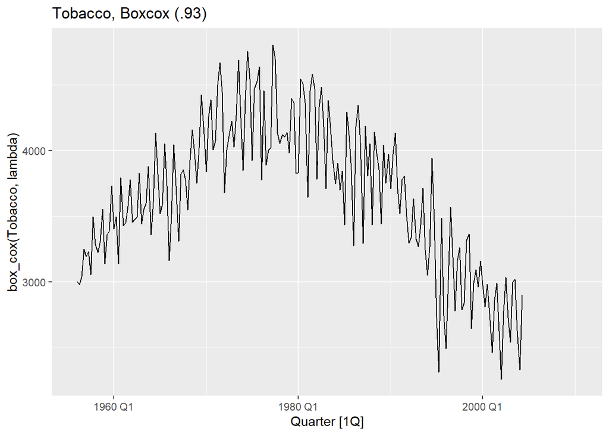

```
## [1] 0.9264636
```

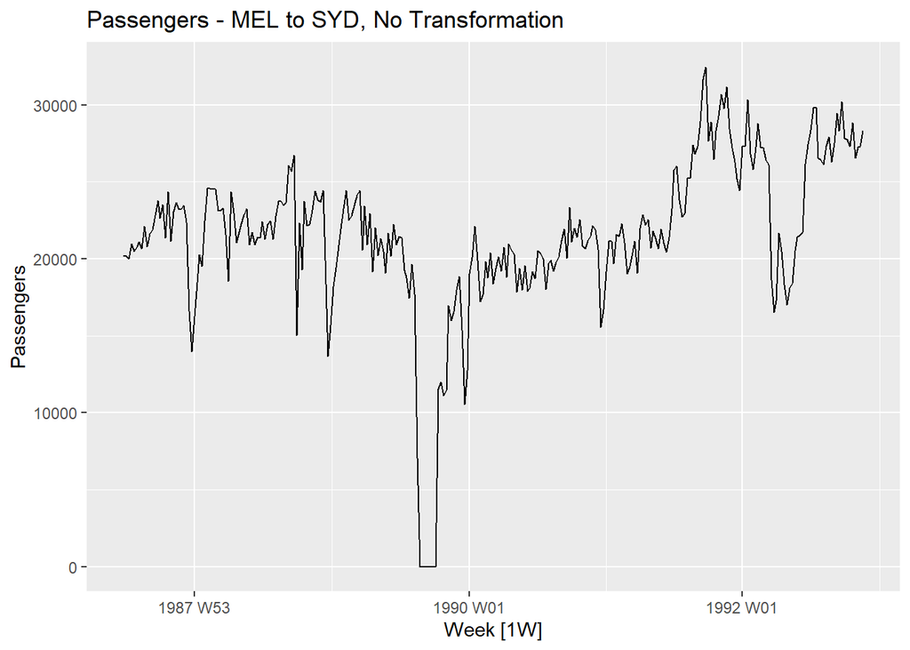

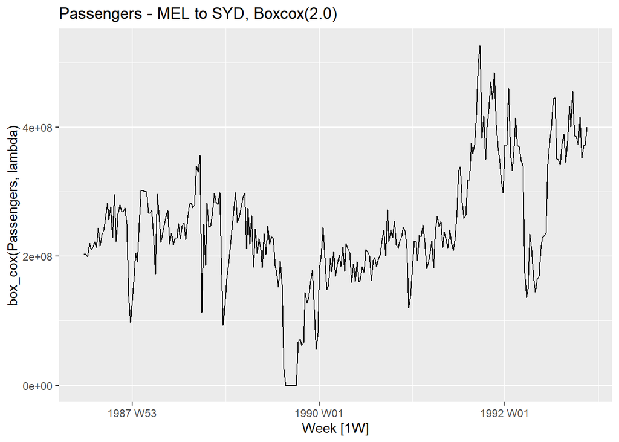

```
## [1] 1.999927
```

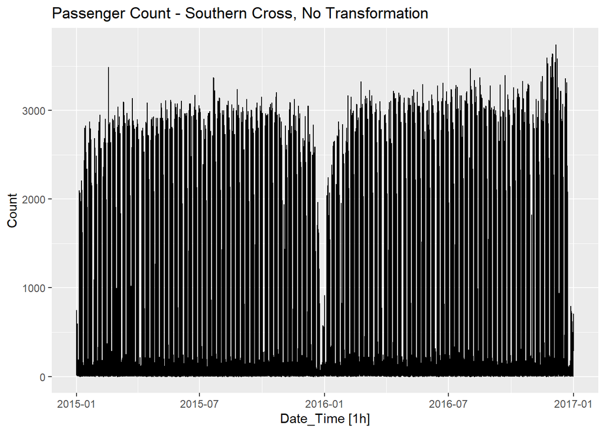

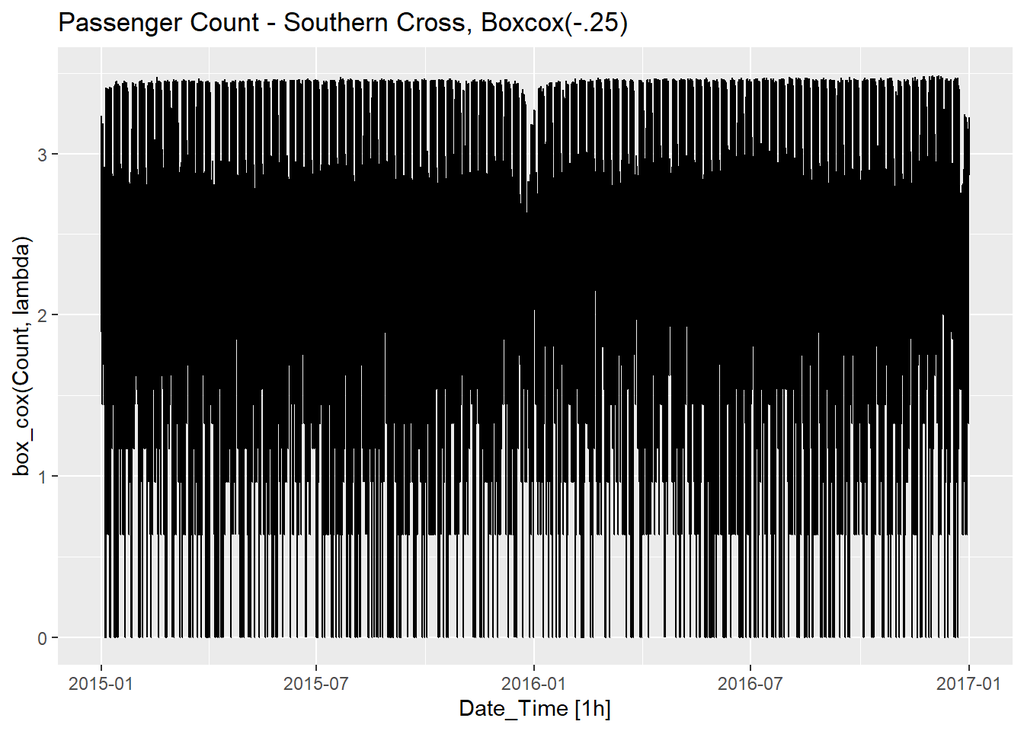

```
## [1] -0.2501616
```

*7. Consider the last five years of the Gas data from aus_production. Plot the time series. Can you identify seasonal fluctuations and/or a trend-cycle?*

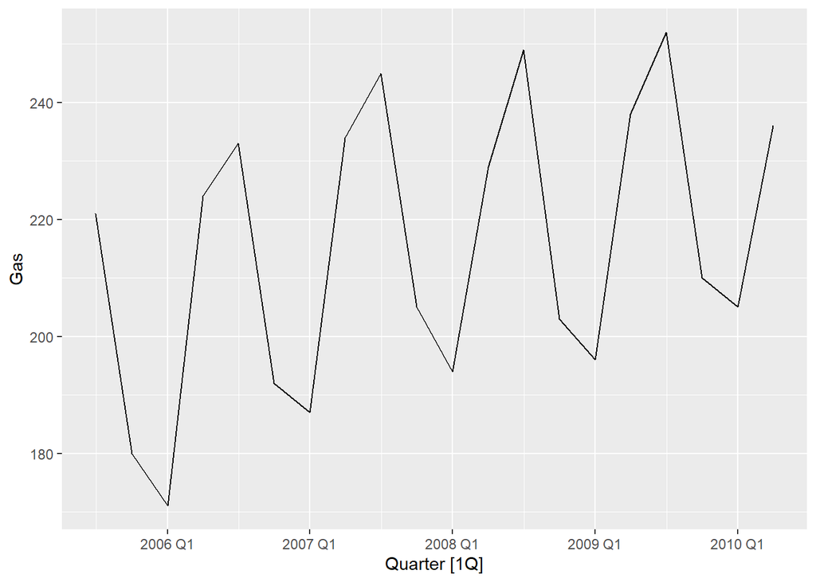

*7.b Use classical_decomposition with type=multiplicative to calculate the trend-cycle and seasonal indices.*

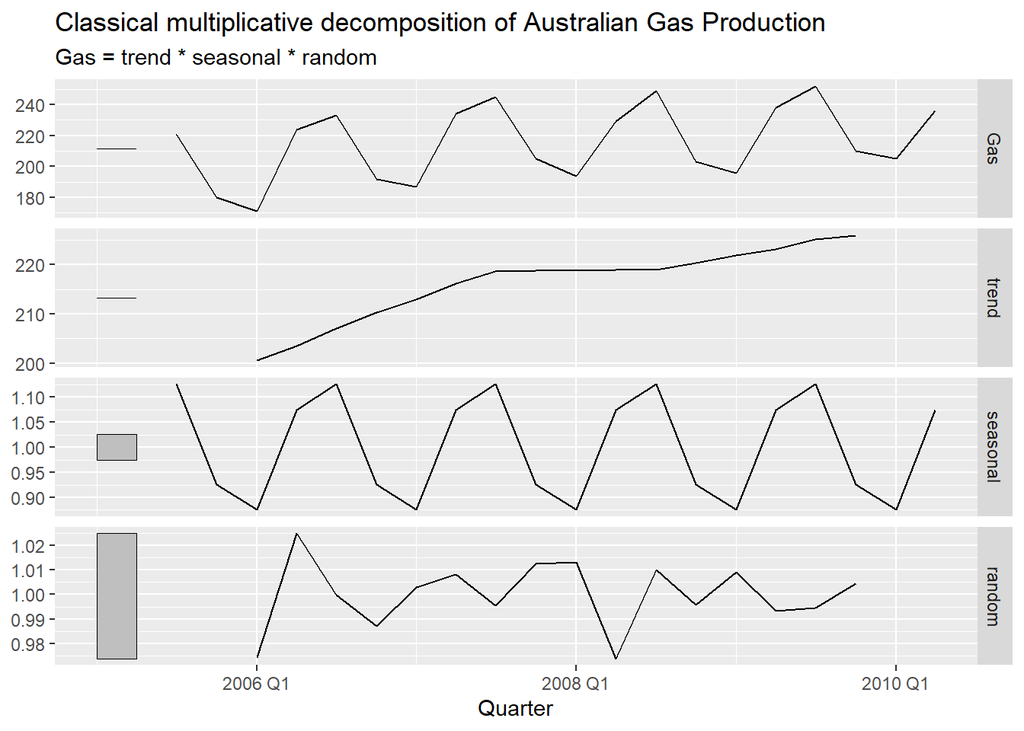

*7.c Do the results support the graphical interpretation from part a?*

Yes, the results are supported.

*7.d Compute and plot the seasonally adjusted data.*

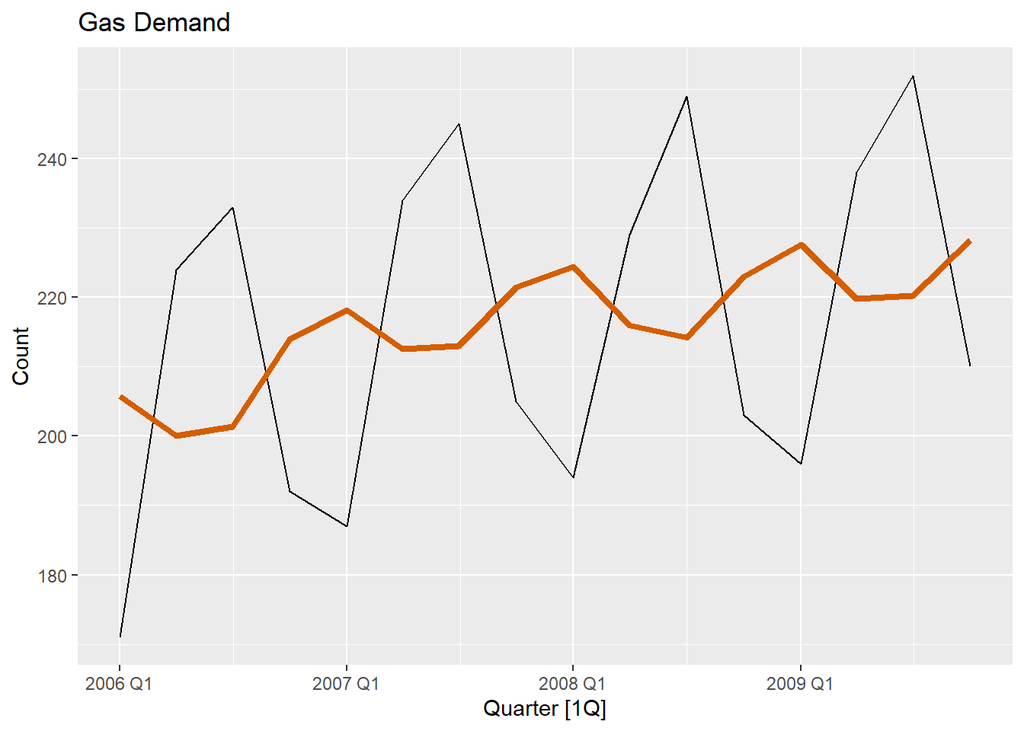

**7.e Change one observation to be an outlier (e.g., add 300 to one observation), and recompute the seasonally adjusted data. What is the effect of the outlier? Does it make any difference if the outlier is near the end rather than in the middle of the time series?**

Outliers have a significant effect on seasonal adjustment. However the effect is temporary, as it tends to wash out before and after the adjustment window. Early and late outliers have more effect snce they are not baanced in the same way.

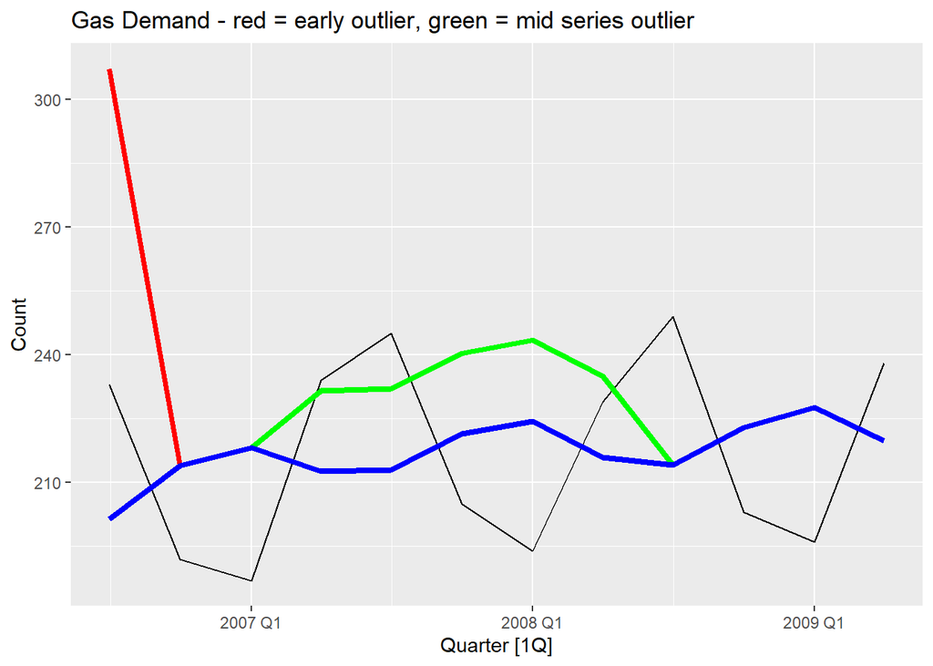

**8. Recall your retail time series data (from Exercise 8 in Section 2.10). Decompose the series using X-11. Does it reveal any outliers, or unusual features that you had not noticed previously?**

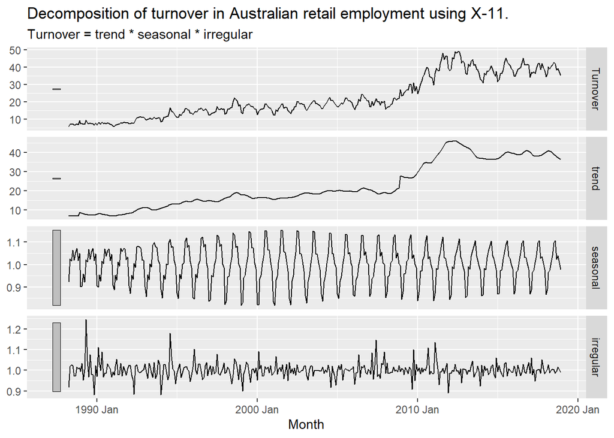

The decomposition reveals a number of things - seasonality is highest in the middle years of the series, not the end as I had thought, and there are some significant outliers in the 1990s.